# Welcome

2025-06-04

This site gathers and describes all scripts used for the analysis of single-cell RNA sequencing (scRNA-Seq), from raw count matrices to figure presented in the publication.

Radomska *et al.*, Glial-to-mesenchymal transition of tumor Schwann cells drives the genetic burden in MPNSTs from Neurofibromatosis type 1 mouse model,  
Science Advances; doi: *not yet available*

All computational analyses were conducted using R language within RStudio. R Markdown (RMD) files were compiled to generate static HTML files, which are shared through this site. Once a file is open, a link in the top left corner enables to open it in a new tab. In the top right corner, the button “Code” allows to download the RMD file behind the HTML.

# Data availability

| Content | Availability |
| --- | --- |
| scRNA-Seq data | ArrayExpress, accession number E-MTAB-14222 |
| R Markdown files | GitHub repository hosting this website |
| Singularity container | Zenodo, record ID 15512051 |

# Data presentation

Several datasets were analyzed in the article, whose main characteristics are described in the tables below.

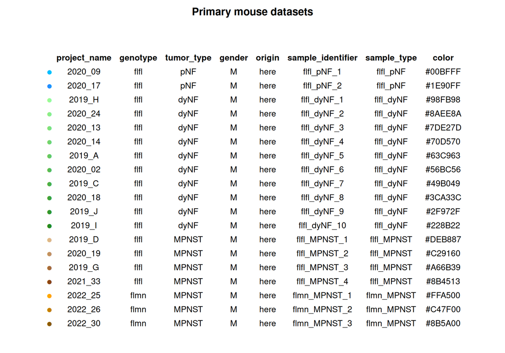

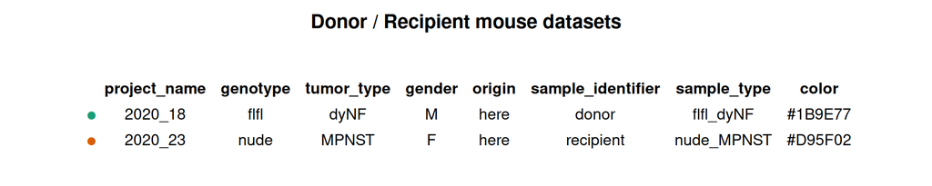

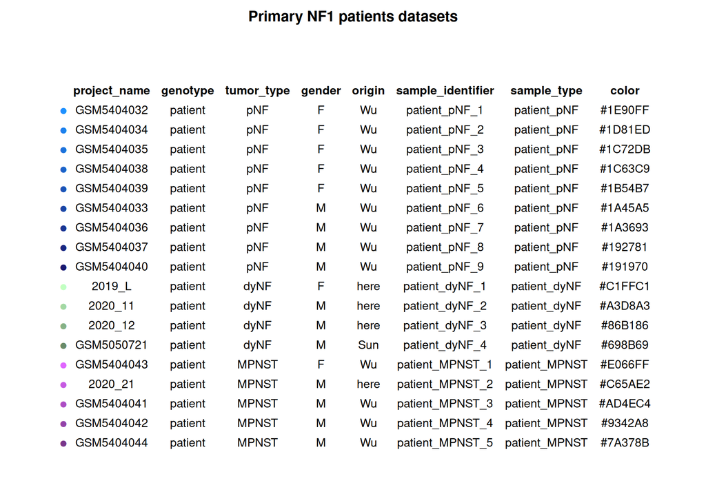

# Analysis framework

Analyses were conducted in specific directories, organised in a tree as shown below:

```bash
cat tree.txt
```

```
## # tree -n -P "*Rmd" ./.. > tree.txt
##
## ./..
## ├── 0_intro
## │   └── 1_welcome.Rmd
## ├── 1_mice
## │   ├── 0_input
## │   ├── 1_metadata
## │   │   └── 1_build_metadata.Rmd
## │   ├── 2_individual
## │   │   ├── 2_make_individual.Rmd
## │   │   └── datasets
## │   ├── 3_combined_mpnst
## │   │   └── 1_combined_mpnst.Rmd
## │   ├── 4_combined_flfl
## │   │   └── 1_combined_flfl.Rmd
## │   ├── 5_tumor_cells
## │   │   ├── 1_tumor_cells_dataset.Rmd
## │   │   ├── 2_trajectory_tinga.Rmd
## │   │   ├── 3_trajectory_slingshot.Rmd
## │   │   ├── 4_functional_enrichment.Rmd
## │   │   └── 5_gsea_heatmap.Rmd
## │   └── 6_fibroblasts
## │       ├── 1_fibroblasts_dataset.Rmd
## │       └── 2_fibroblasts_analysis.Rmd
## ├── 2_patients
## │   ├── 0_input
## │   │   ├── 2019_L
## │   │   ├── 2020_11
## │   │   ├── 2020_12
## │   │   ├── 2020_21
## │   │   ├── GSM5050721
## │   │   ├── GSM5404032
## │   │   ├── GSM5404033
## │   │   ├── GSM5404034
## │   │   ├── GSM5404035
## │   │   ├── GSM5404036
## │   │   ├── GSM5404037
## │   │   ├── GSM5404038
## │   │   ├── GSM5404039
```

[output cut: 29 more lines]

```
## │   ├── 3_combined
## │   │   └── 3_combined_graft.Rmd
## │   └── 4_tumor_cells
## │       ├── 41_tumor_cells_dataset.Rmd
## │       ├── 42_trajectory_tinga.Rmd
## │       └── 43_trajectory_slingshot.Rmd
## ├── 4_figures
## │   ├── data
## │   ├── figures_detail
## │   └── figures.Rmd
## └── index_layout
##     ├── logo
##     └── pages
##
## 54 directories, 26 files
```

Note that the menu on the left follows almost the same structure.

# RMD knitting

R Markdown (RMD) notebooks were developed within R Studio. To ensure the reproducibility of all the analyses from the raw count matrices to the final figures and results, the RMD files were compiled using a Singularity container, to generate the HTML pages presented here. Excepting the notebooks focusing on individual dataset, all notebooks are parameter-free, so that they can be compiled using the same command. The following template was used:

```bash
file="FILE_NAME"
singularity exec \
--bind /home \
/path/to/singularity/image/singularity.simg \
Rscript -e "rmarkdown::render(input = '${file}.Rmd', output_file = '${file}.html')"
```

Since R libraries are not located at the same location within the Singularity container or on the local machine, we add the `.libPaths()` R command at the beginning of each notebook. In the compiled HTML file, we thus can easily check if the notebook was compiled through the container or not.

# Index page

The static website was built using OrganizeHTML (DOI: 10.5281/zenodo.14505634)

–end–